# P6- Améliorez le produit IA de votre start-up

# Partie I : TOPIC MODELING

```
True
```

|  | File_name |
| --- | --- |
| 0 | buisness.csv |
| 1 | chekin.csv |
| 2 | review.csv |
| 3 | tip.csv |
| 4 | user.csv |

## Get raw files paths

```
['C:\\Users\\AMC\\Desktop\\Still_on_P\\Projet - 06 - En cours\\yelp_dataset\\raw_files\\buisness.csv',
 'C:\\Users\\AMC\\Desktop\\Still_on_P\\Projet - 06 - En cours\\yelp_dataset\\raw_files\\chekin.csv',
 'C:\\Users\\AMC\\Desktop\\Still_on_P\\Projet - 06 - En cours\\yelp_dataset\\raw_files\\review.csv',
 'C:\\Users\\AMC\\Desktop\\Still_on_P\\Projet - 06 - En cours\\yelp_dataset\\raw_files\\tip.csv',
 'C:\\Users\\AMC\\Desktop\\Still_on_P\\Projet - 06 - En cours\\yelp_dataset\\raw_files\\user.csv']
```

## load raw files and prepare data :

### business file :

```
File is    : C:\Users\AMC\Desktop\Still_on_P\Projet - 06 - En cours\yelp_dataset\raw_files\buisness.csv
```

|  | business_id | name | address | city | state | postal_code | latitude | longitude | stars | review_count | is_open | attributes | categories | hours |
| --- | --- | --- | --- | --- | --- | --- | --- | --- | --- | --- | --- | --- | --- | --- |
| 0 | Pns2l4eNsfO8kk83dixA6A | Abby Rappoport, LAC, CMQ | 1616 Chapala St, Ste 2 | Santa Barbara | CA | 93101 | 34.426679 | -119.711197 | 5.0 | 7 | 0 | {'ByAppointmentOnly': 'True'} | Doctors, Traditional Chinese Medicine, Naturop... | NaN |
| 1 | mpf3x-BjTdTEA3yCZrAYPw | The UPS Store | 87 Grasso Plaza Shopping Center | Affton | MO | 63123 | 38.551126 | -90.335695 | 3.0 | 15 | 1 | {'BusinessAcceptsCreditCards': 'True'} | Shipping Centers, Local Services, Notaries, Ma... | {'Monday': '0:0-0:0', 'Tuesday': '8:0-18:30', ... |

### Chek-in file :

```
File is    : C:\Users\AMC\Desktop\Still_on_P\Projet - 06 - En cours\yelp_dataset\raw_files\chekin.csv
```

|  | business_id | date |
| --- | --- | --- |
| 0 | ---kPU91CF4Lq2-WlRu9Lw | 2020-03-13 21:10:56, 2020-06-02 22:18:06, 2020... |
| 1 | --0iUa4sNDFiZFrAdIWhZQ | 2010-09-13 21:43:09, 2011-05-04 23:08:15, 2011... |

### review file :

```
File is    : C:\Users\AMC\Desktop\Still_on_P\Projet - 06 - En cours\yelp_dataset\raw_files\review.csv
```

|  | review_id | user_id | business_id | stars | useful | funny | cool | text | date |
| --- | --- | --- | --- | --- | --- | --- | --- | --- | --- |
| 0 | KU_O5udG6zpxOg-VcAEodg | mh_-eMZ6K5RLWhZyISBhwA | XQfwVwDr-v0ZS3_CbbE5Xw | 3 | 0 | 0 | 0 | If you decide to eat here, just be aware it is... | 2018-07-07 22:09:11 |
| 1 | BiTunyQ73aT9WBnpR9DZGw | OyoGAe7OKpv6SyGZT5g77Q | 7ATYjTIgM3jUlt4UM3IypQ | 5 | 1 | 0 | 1 | I've taken a lot of spin classes over the year... | 2012-01-03 15:28:18 |

### Tip file :

```
File is    : C:\Users\AMC\Desktop\Still_on_P\Projet - 06 - En cours\yelp_dataset\raw_files\tip.csv
```

|  | user_id | business_id | text | date | compliment_count |
| --- | --- | --- | --- | --- | --- |
| 0 | AGNUgVwnZUey3gcPCJ76iw | 3uLgwr0qeCNMjKenHJwPGQ | Avengers time with the ladies. | 2012-05-18 02:17:21 | 0 |
| 1 | NBN4MgHP9D3cw--SnauTkA | QoezRbYQncpRqyrLH6Iqjg | They have lots of good deserts and tasty cuban... | 2013-02-05 18:35:10 | 0 |

### User file :

```
File is    : C:\Users\AMC\Desktop\Still_on_P\Projet - 06 - En cours\yelp_dataset\raw_files\user.csv
```

|  | user_id | name | review_count | yelping_since | useful | funny | cool | elite | friends | fans | ... | compliment_more | compliment_profile | compliment_cute | compliment_list | compliment_note | compliment_plain | compliment_cool | compliment_funny | compliment_writer | compliment_photos |
| --- | --- | --- | --- | --- | --- | --- | --- | --- | --- | --- | --- | --- | --- | --- | --- | --- | --- | --- | --- | --- | --- |
| 0 | qVc8ODYU5SZjKXVBgXdI7w | Walker | 585 | 2007-01-25 16:47:26 | 7217 | 1259 | 5994 | 2007 | NSCy54eWehBJyZdG2iE84w, pe42u7DcCH2QmI81NX-8qA... | 267 | ... | 65 | 55 | 56 | 18 | 232 | 844 | 467 | 467 | 239 | 180 |

1 rows × 22 columns

## Conclusion on raw data and which we are going to use :

Les fichiers a utiliser sont :

```
1- df_business : source of business_ids (contains not only restauration)

2- df_review : holds all reviews to be studied
```

### Load Dataframe 'df_buisness' and extract rows related to restauration only:

```
File is    : C:\Users\AMC\Desktop\Still_on_P\Projet - 06 - En cours\yelp_dataset\raw_files\buisness.csv
df_business shape   : (150346, 14)
```

|  | business_id | name | address | city | state | postal_code | latitude | longitude | stars | review_count | is_open | attributes | categories | hours |
| --- | --- | --- | --- | --- | --- | --- | --- | --- | --- | --- | --- | --- | --- | --- |
| 0 | Pns2l4eNsfO8kk83dixA6A | Abby Rappoport, LAC, CMQ | 1616 Chapala St, Ste 2 | Santa Barbara | CA | 93101 | 34.426679 | -119.711197 | 5.0 | 7 | 0 | {'ByAppointmentOnly': 'True'} | Doctors, Traditional Chinese Medicine, Naturop... | NaN |
| 1 | mpf3x-BjTdTEA3yCZrAYPw | The UPS Store | 87 Grasso Plaza Shopping Center | Affton | MO | 63123 | 38.551126 | -90.335695 | 3.0 | 15 | 1 | {'BusinessAcceptsCreditCards': 'True'} | Shipping Centers, Local Services, Notaries, Ma... | {'Monday': '0:0-0:0', 'Tuesday': '8:0-18:30', ... |

### Define keywords related to restauration activity to extract coressponding business_ids

```
(64629, 14)
```

```
0
```

```
0
```

```
0
```

```
0
```

```
3uLgwr0qeCNMjKenHJwPGQ    1
QoezRbYQncpRqyrLH6Iqjg    1
MYoRNLb5chwjQe3c_k37Gg    1
hV-bABTK-glh5wj31ps_Jw    1
_uN0OudeJ3Zl_tf6nxg5ww    1
7Rm9Ba50bw23KTA8RedZYg    1
kH-0iXqkL7b8UXNpguBMKg    1
jtri188kuhe_AuEOJ51U_A    1
xODBZmX4EmlVvbqtKN7YKg    1
pICJRcyqW1cF96Q3XhLSbw    1
Name: business_id, dtype: int64
```

```
AGNUgVwnZUey3gcPCJ76iw    1
NBN4MgHP9D3cw--SnauTkA    1
-copOvldyKh1qr-vzkDEvw    1
FjMQVZjSqY8syIO-53KFKw    1
ld0AperBXk1h6UbqmM80zw    1
trf3Qcz8qvCDKXiTgjUcEg    1
SMGAlRjyfuYu-c-22zIyOg    1
YVBB9g23nuVJ0u44zK0pSA    1
VL12EhEdT4OWqGq0nIqkzw    1
4ay-fdVks5WMerYL_htkGQ    1
Name: user_id, dtype: int64
```

```
0    10
Name: compliment_count, dtype: int64
```

### Load only bad review extracted from original file :

### Bad reviews are all reviews with notation stars equal to '1'

```
(688516, 10)
```

|  | review_id | user_id | business_id | stars | useful | funny | cool | text | date | status |
| --- | --- | --- | --- | --- | --- | --- | --- | --- | --- | --- |
| 0 | JrIxlS1TzJ-iCu79ul40cQ | eUta8W_HdHMXPzLBBZhL1A | 04UD14gamNjLY0IDYVhHJg | 1 | 1 | 2 | 1 | I am a long term frequent customer of this est... | 2015-09-23 23:10:31 | 1 |

|  | business_id | name | address | city | state | postal_code | latitude | longitude | stars | review_count | is_open | attributes | categories | hours |
| --- | --- | --- | --- | --- | --- | --- | --- | --- | --- | --- | --- | --- | --- | --- |
| 3 | MTSW4McQd7CbVtyjqoe9mw | St Honore Pastries | 935 Race St | Philadelphia | PA | 19107 | 39.955505 | -75.155564 | 4.0 | 80 | 1 | {'RestaurantsDelivery': 'False', 'OutdoorSeati... | restaurants, food, bubble tea, coffee & tea, b... | {'Monday': '7:0-20:0', 'Tuesday': '7:0-20:0', ... |

```
64629
```

```
(688516, 10)
```

```
Index(['review_id', 'user_id', 'business_id', 'stars', 'useful', 'funny',
       'cool', 'text', 'date', 'status'],
      dtype='object')
```

### Divide original dataframe to avoid memory issues when running

### check if all reviews are related to df_buz 'business_id''

```
hello, work in progress...
```

```
step reached   : 1000 ______Time elapsed   : -0.0016028000027290545
step reached   : 5000 ______Time elapsed   : -7.439999899361283e-05
step reached   : 7000 ______Time elapsed   : -0.0010694000011426397
step reached   : 10000 ______Time elapsed   : 0.003304499994555954
step reached   : 20000 ______Time elapsed   : -0.0009907000057864934
step reached   : 50000 ______Time elapsed   : -0.001119499997003004
step reached   : 70000 ______Time elapsed   : -0.0008104000007733703
step reached   : 85000 ______Time elapsed   : -0.0008177999989129603
step reached   : 95000 ______Time elapsed   : -0.0008166999978129752
elapsed time   : -0.0008137000040733255
```

|  | review_id | user_id | business_id | stars | useful | funny | cool | text | date | status |
| --- | --- | --- | --- | --- | --- | --- | --- | --- | --- | --- |
| 0 | JrIxlS1TzJ-iCu79ul40cQ | eUta8W_HdHMXPzLBBZhL1A | 04UD14gamNjLY0IDYVhHJg | 1 | 1 | 2 | 1 | I am a long term frequent customer of this est... | 2015-09-23 23:10:31 | 1 |
| 1 | TcCcHzc3L6Aboq3DteEfZA | OuatwND396ZQxm2zK8WlUQ | jNL5KUPz2-tHUJM__ysSaw | 1 | 1 | 0 | 0 | If you want to pay for everything a la carte t... | 2014-08-24 20:14:12 | 1 |
| 2 | qdzNocGBnh8U-cvE_N8qbA | Fq7d14GDAsGjDoojP_ygOQ | pAgtmlIGqFYaWdBoCUeitw | 1 | 3 | 0 | 0 | The TV shows are $4.99 and they have commercia... | 2012-12-04 02:40:49 | 1 |
| 3 | PDHRlnEdkEcwATry4w71PQ | UsBxLh14sUpO8SdeqIiGOA | Wy8Hswf2cLQGRZN6armkag | 1 | 1 | 0 | 0 | If I could give it a zero, I would. I order a ... | 2011-08-24 23:07:08 | 1 |
| 4 | 5obXxR0b94b5q6j1zYCAzw | 3inG_FUhm28tUJc0zZ2fCg | aY_n9RSaD2Yw09jSFFePew | 1 | 0 | 0 | 0 | We visited once and were very disappointed in ... | 2017-08-16 15:43:19 | 1 |
| ... | ... | ... | ... | ... | ... | ... | ... | ... | ... | ... |
| 99995 | ybXRRuHGfMs5kT3pPqLF2Q | ur_twNxgihI8wI2zNeI-xg | ULbd1Bjuvns732BhhWJv3Q | 1 | 1 | 0 | 0 | Too many people for only being open 3.5 hours.... | 2020-10-19 09:03:01 | 1 |
| 99996 | J6A8gnS-coLdGSvd2zsgmg | laKqD_UUU5rox6mARvQggQ | SIoCIxjn4jLt2O-4DajWJw | 1 | 0 | 1 | 0 | Rude bartenders!!! Simply asked what a shot th... | 2019-03-16 20:32:16 | 1 |
| 99997 | 6R-JWbPRqxkncTA3CyQQqQ | Wxbk2CemV8v6dA7WMP5yCg | a7ntsLR4kQX7zpcVgpANgw | 1 | 0 | 0 | 0 | They would not send a person out to give estim... | 2012-08-19 01:44:46 | 1 |
| 99998 | GUB3J8dDZ-3EJ4kH9ARj1w | N26YdWNi8ZBg238ykpci0Q | FKrP06TDAKtxNG1vrRQcQQ | 1 | 0 | 0 | 0 | I came in at 12:04AM. No one would greet or se... | 2016-04-30 06:46:49 | 1 |
| 99999 | GxuJ8vsRVElRFzgX8nVbcQ | e2RFrIKPX0NmSvugir8a9g | _5aUqcRlSkRV32ik88xSKg | 1 | 0 | 0 | 0 | They don't listen to deliver instructions. Min... | 2021-11-11 14:11:31 | 1 |

100000 rows × 10 columns

```
1    100000
Name: status, dtype: int64
```

```
hello, work in progress...
```

```
step reached   : 1000 ______Time elapsed   : -0.002122699996107258
step reached   : 5000 ______Time elapsed   : -0.0017789999983506277
step reached   : 7000 ______Time elapsed   : -0.0020069999955012463
step reached   : 10000 ______Time elapsed   : -0.0022622999968007207
step reached   : 20000 ______Time elapsed   : -0.001969299999473151
step reached   : 30000 ______Time elapsed   : -0.002270899996801745
step reached   : 40000 ______Time elapsed   : -0.0019378999932087027
step reached   : 50000 ______Time elapsed   : -0.001954399995156564
step reached   : 70000 ______Time elapsed   : -0.0025393999967491254
step reached   : 85000 ______Time elapsed   : -0.0015985999998520128
step reached   : 95000 ______Time elapsed   : -0.001883999997517094
elapsed time   : -0.0018265999970026314
```

```
0    100000
Name: status, dtype: int64
```

```
hello, work in progress...
```

```
step reached   : 1000 ______Time elapsed   : 0.0006615000020246953
step reached   : 5000 ______Time elapsed   : 0.0006318000014289282
step reached   : 7000 ______Time elapsed   : -2.1299994841683656e-05
step reached   : 10000 ______Time elapsed   : -0.00013689999468624592
step reached   : 20000 ______Time elapsed   : -0.00012289999722270295
step reached   : 30000 ______Time elapsed   : -0.00038279998989310116
step reached   : 40000 ______Time elapsed   : -4.8499998229090124e-05
step reached   : 50000 ______Time elapsed   : 0.0009543000051053241
step reached   : 70000 ______Time elapsed   : -0.0002423999976599589
step reached   : 85000 ______Time elapsed   : 0.00011290000838926062
step reached   : 95000 ______Time elapsed   : -0.00022659999376628548
elapsed time   : 0.00021660000493284315
```

```
0    100000
Name: status, dtype: int64
```

```
hello, work in progress...
```

```
step reached   : 1000 ______Time elapsed   : 0.001517299999250099
step reached   : 5000 ______Time elapsed   : -0.000870000003487803
step reached   : 7000 ______Time elapsed   : -0.0017582000000402331
step reached   : 10000 ______Time elapsed   : -0.002060999999230262
step reached   : 20000 ______Time elapsed   : 0.0029313999984879047
step reached   : 30000 ______Time elapsed   : -0.0017479000016464852
step reached   : 40000 ______Time elapsed   : -0.001593700006196741
step reached   : 50000 ______Time elapsed   : 0.0010341999950469472
step reached   : 70000 ______Time elapsed   : -0.0014775000017834827
step reached   : 85000 ______Time elapsed   : -0.0016882000054465607
step reached   : 95000 ______Time elapsed   : -0.0017876000056276098
elapsed time   : -0.0017260000022361055
```

```
1    100000
Name: status, dtype: int64
```

```
hello, work in progress...
```

```
step reached   : 1000 ______Time elapsed   : -0.0009442000009585172
step reached   : 5000 ______Time elapsed   : -0.0004078999991179444
step reached   : 7000 ______Time elapsed   : -0.0006624999950872734
step reached   : 10000 ______Time elapsed   : -0.0007686999961151741
step reached   : 20000 ______Time elapsed   : 0.0014458000005106442
step reached   : 30000 ______Time elapsed   : -0.0008229000013670884
step reached   : 40000 ______Time elapsed   : -0.00019780000002356246
step reached   : 50000 ______Time elapsed   : -0.0010274000014760531
step reached   : 70000 ______Time elapsed   : -0.0007748000061837956
step reached   : 85000 ______Time elapsed   : -0.0005078999965917319
step reached   : 95000 ______Time elapsed   : -0.0007763000030536205
elapsed time   : -0.0008039000022108667
```

```
1    100000
Name: status, dtype: int64
```

```
hello, work in progress...
```

```
step reached   : 1000 ______Time elapsed   : -0.00023770000552758574
step reached   : 5000 ______Time elapsed   : 0.0015365999934147112
step reached   : 7000 ______Time elapsed   : -0.0002314000012120232
step reached   : 10000 ______Time elapsed   : -0.00019939999765483662
step reached   : 20000 ______Time elapsed   : 0.0035212000002502464
step reached   : 30000 ______Time elapsed   : -0.00011330001143505797
step reached   : 40000 ______Time elapsed   : 0.0013270999988890253
step reached   : 50000 ______Time elapsed   : 0.004369499998574611
step reached   : 70000 ______Time elapsed   : 0.0009434000021428801
step reached   : 85000 ______Time elapsed   : 9.49999230215326e-06
elapsed time   : 0.0034449999875505455
```

```
1    88516
Name: status, dtype: int64
```

### conclusion :

2- we concatenate the rest of df_br(i) to get final dataframe for use.

```
1    688516
Name: stars, dtype: int64
```

|  | review_id | user_id | business_id | stars | useful | funny | cool | text | date | status |
| --- | --- | --- | --- | --- | --- | --- | --- | --- | --- | --- |
| 0 | JrIxlS1TzJ-iCu79ul40cQ | eUta8W_HdHMXPzLBBZhL1A | 04UD14gamNjLY0IDYVhHJg | 1 | 1 | 2 | 1 | I am a long term frequent customer of this est... | 2015-09-23 23:10:31 | 1 |
| 1 | TcCcHzc3L6Aboq3DteEfZA | OuatwND396ZQxm2zK8WlUQ | jNL5KUPz2-tHUJM__ysSaw | 1 | 1 | 0 | 0 | If you want to pay for everything a la carte t... | 2014-08-24 20:14:12 | 1 |
| 2 | qdzNocGBnh8U-cvE_N8qbA | Fq7d14GDAsGjDoojP_ygOQ | pAgtmlIGqFYaWdBoCUeitw | 1 | 3 | 0 | 0 | The TV shows are $4.99 and they have commercia... | 2012-12-04 02:40:49 | 1 |
| 3 | PDHRlnEdkEcwATry4w71PQ | UsBxLh14sUpO8SdeqIiGOA | Wy8Hswf2cLQGRZN6armkag | 1 | 1 | 0 | 0 | If I could give it a zero, I would. I order a ... | 2011-08-24 23:07:08 | 1 |
| 4 | 5obXxR0b94b5q6j1zYCAzw | 3inG_FUhm28tUJc0zZ2fCg | aY_n9RSaD2Yw09jSFFePew | 1 | 0 | 0 | 0 | We visited once and were very disappointed in ... | 2017-08-16 15:43:19 | 1 |

```
(388516, 10)
```

## Data cleaning and processing :

```
<class 'pandas.core.frame.DataFrame'>
RangeIndex: 388516 entries, 0 to 388515
Data columns (total 11 columns):
 #   Column       Non-Null Count   Dtype
---  ------       --------------   -----
 0   Unnamed: 0   388516 non-null  Int64
 1   review_id    388516 non-null  string
 2   user_id      388516 non-null  string
 3   business_id  388516 non-null  string
 4   stars        388516 non-null  Int64
 5   useful       388516 non-null  Int64
 6   funny        388516 non-null  Int64
 7   cool         388516 non-null  Int64
 8   text         388516 non-null  string
 9   date         388516 non-null  string
 10  status       388516 non-null  Int64
dtypes: Int64(6), string(5)
memory usage: 34.8 MB
```

```
***************Cleaning ok
0    i am a long term frequent customer of this est...
1    if you want to pay for everything a la carte t...
Name: text, dtype: object
```

```
***************Tokenization & Stop-words removed ok
0    [long, term, frequent, customer, establishment...
1    [want, pay, everything, la, carte, place, food...
Name: text, dtype: object
```

```
***************Lemmatization ok
0    [long, term, frequent, customer, establishment...
1    [want, pay, everything, la, carte, place, food...
Name: text, dtype: object
```

## Buiding NMF Model for topics extraction:

|  | Unnamed: 0.1 | Unnamed: 0 | review_id | business_id | stars | text | date | status |
| --- | --- | --- | --- | --- | --- | --- | --- | --- |
| 0 | 0 | 0 | JrIxlS1TzJ-iCu79ul40cQ | 04UD14gamNjLY0IDYVhHJg | 1 | ['long', 'term', 'frequent', 'customer', 'esta... | 2015-09-23 23:10:31 | 1 |
| 1 | 1 | 1 | TcCcHzc3L6Aboq3DteEfZA | jNL5KUPz2-tHUJM__ysSaw | 1 | ['want', 'pay', 'everything', 'la', 'carte', '... | 2014-08-24 20:14:12 | 1 |
| 2 | 2 | 2 | qdzNocGBnh8U-cvE_N8qbA | pAgtmlIGqFYaWdBoCUeitw | 1 | ['tv', 'show', '499', 'commercial', 'cheesy', ... | 2012-12-04 02:40:49 | 1 |

## Final topics :

```
(388516, 13044)
```

```
NMF(n_components=5, random_state=0)
```

```
((388516, 13044), (388516, 5), (5, 13044))
```

|  | 100 | 100x | 101 | 1010 | 1012 | 1014 | 1015 | 102 | 1020 | 1025 | ... | zen | zero | zip | zipper | ziti | zombie | zone | zoo | zoom | zucchini |
| --- | --- | --- | --- | --- | --- | --- | --- | --- | --- | --- | --- | --- | --- | --- | --- | --- | --- | --- | --- | --- | --- |
| 0 | 0.005341 | 0.000931 | 0.008909 | 0.004721 | 0.004136 | 0.002717 | 0.009966 | 0.004527 | 0.004233 | 0.002344 | ... | 0.002091 | 0.182085 | 0.013943 | 0.009269 | 0.000000 | 0.004794 | 0.019961 | 0.009730 | 0.005576 | 0.000000 |
| 1 | 0.000306 | 0.002248 | 0.001772 | 0.003026 | 0.001216 | 0.000000 | 0.000000 | 0.000000 | 0.000000 | 0.000056 | ... | 0.001369 | 0.058743 | 0.000000 | 0.000000 | 0.006993 | 0.002510 | 0.001670 | 0.004964 | 0.000000 | 0.015439 |
| 2 | 0.000000 | 0.000000 | 0.001717 | 0.003742 | 0.004471 | 0.000380 | 0.063479 | 0.000418 | 0.008648 | 0.001523 | ... | 0.000728 | 0.019143 | 0.000000 | 0.000000 | 0.000000 | 0.001173 | 0.002489 | 0.000000 | 0.000000 | 0.000000 |
| 3 | 0.000000 | 0.000000 | 0.000000 | 0.000581 | 0.000279 | 0.000066 | 0.000000 | 0.000311 | 0.002310 | 0.000000 | ... | 0.000000 | 0.024222 | 0.000375 | 0.000000 | 0.007457 | 0.000019 | 0.001802 | 0.000000 | 0.000574 | 0.000840 |
| 4 | 0.000000 | 0.000841 | 0.004911 | 0.002644 | 0.000000 | 0.000000 | 0.000000 | 0.000000 | 0.000000 | 0.000000 | ... | 0.000000 | 0.219889 | 0.000873 | 0.000000 | 0.000000 | 0.000863 | 0.000272 | 0.000000 | 0.000000 | 0.000000 |

5 rows × 13044 columns

```
0       time
1       food
2      order
3      pizza
4    service
dtype: object
```

```
For topic 1 the words with the highest value are:
```

|  | 0 |
| --- | --- |
| time | 1.791017 |
| day | 1.597700 |
| call | 1.557296 |
| one | 1.432448 |
| company | 1.060812 |

```
Review related to review    : *** time ***      with a specific weight   :** 1.7910171378470559
```

```
"['st', 'louis', 'kc', 'stopped', 'calecos', 'rumored', 'authentic', 'st', 'louis', 'dish', 'bad', 'idea', 'clean', 'friendly', 'server', 'food', 'good', 'greasy', 'spoon', 'italian', 'famous', 'gooey', 'butter', 'cake', 'tasted', 'like', 'cooked', 'last', 'year', 'lasagna', 'pan', 'ick']"
```

```
Original review ___________
```

```
'We were in St. Louis from KC, and stopped at Caleco\'s because it was rumored to have authentic St. Louis dishes. Bad idea. Not clean. Not friendly servers. The food was not good, more of greasy spoon than Italian. And the "famous" gooey butter cake tasted like it was cooked in last year\'s lasagna…
```

```
For topic 2 the words with the highest value are:
```

|  | 1 |
| --- | --- |
| food | 3.878075 |
| place | 1.706969 |
| good | 1.435786 |
| chicken | 1.390921 |
| like | 1.241856 |

```
Review related to review    : *** food ***      with a specific weight   :** 3.8780754379001268
```

```
"['second', 'chance', 'anthony', 'never', 'return', 'time', 'pizza', 'dry', 'cooked', 'salad', 'incomplete', 'best', 'pricey', 'definitely', 'worth', 'sad', 'live', 'close']"
```

```
Original review ___________
```

```
'This was The "second chance" for Anthony\'s  and I will never return.  Both times the pizza was very dry and over cooked. The salad was incomplete at best! Pricey and DEFINITELY not worth it! Sad because I live so close!'
```

```
For topic 3 the words with the highest value are:
```

|  | 2 |
| --- | --- |
| order | 2.969299 |
| minute | 2.708445 |
| table | 1.935044 |
| drink | 1.480024 |
| waited | 1.288419 |

```
Review related to review    : *** order ***      with a specific weight   :** 2.9692991374902653
```

```
"['normally', 'write', 'negative', 'review', 'experience', 'particularly', 'disappointing', 'went', 'nox', 'husband', 'two', 'week', 'ago', 'stopping', 'work', 'romantic', 'relaxing', 'evening', 'sat', 'patio', 'modern', 'inviting', 'hostess', 'extremely', 'courteous', 'chatted', 'u', 'minute', 'wai…
```

```
Original review ___________
```

```
"I don't normally write negative reviews, but my experience was particularly disappointing here. I went to Nox with my husband two weeks ago. We were stopping by after work for a romantic, relaxing evening out. We sat on their patio, which was very modern and inviting. The hostess was extremely cour…
```

```
For topic 4 the words with the highest value are:
```

|  | 3 |
| --- | --- |
| pizza | 5.578733 |
| order | 0.892017 |
| cheese | 0.704165 |
| delivery | 0.681486 |
| crust | 0.477019 |

```
Review related to review    : *** pizza ***      with a specific weight   :** 5.5787325444127305
```

```
"['got', 'grubhub', 'delivery', 'sushi', 'inedible', 'lunch', 'special', 'three', 'roll', 'brown', 'rice', 'brown', 'rice', 'mush', 'raw', 'fish', 'warm', 'wet', 'tried', 'couple', 'piece', 'weird', 'plastic', 'taste', 'threw', 'rest', 'ive', 'exact', 'thing', 'great', 'disappointed', 'wasted']"
```

```
Original review ___________
```

```
'I just got a grubhub delivery and the sushi is inedible. I ordered the lunch special three rolls with brown rice. The brown rice was mush and the raw fish was warm and wet. I tried a couple pieces and all had a weird plastic taste. I threw the rest out. Ive ordered the exact thing before and it was…
```

```
For topic 5 the words with the highest value are:
```

|  | 4 |
| --- | --- |
| service | 3.962450 |
| customer | 3.009257 |
| rude | 1.598897 |
| worst | 1.352650 |
| horrible | 1.327708 |

```
Review related to review    : *** service ***      with a specific weight   :** 3.9624499714844936
```

```
"['sweat', 'better', 'gym', 'planet', 'fitness', 'better', 'deal', 'overall', 'gym', 'decent', 'member', 'however', 'equipment', 'broken', 'took', 'least', 'day', 'fix', 'watch', 'hidden', 'fee', 'fine', 'print', 'contract', 'tried', 'cancel', 'membership', 'expected', 'early', 'cancellation', 'fee'…
```

```
Original review ___________
```

```
"Go to Sweat for a better gym and Planet Fitness for a better deal. Overall this gym was decent while I was a member. However, when equipment was broken it took them at least 10 days to fix it. Watch out for hidden fees and fine print on their contracts. When I tried to cancel my membership I expect…
```

```
((139919, 7), (110102, 7), (111016, 7), (15160, 7), (122507, 7))
```

```
4                                                                                                                                                                                                                                                                                                           …
7                                                                                                                                                                                                                                                                                                           …
8                                                                                                                                                                                                                                                                                                           …
13                                                                                                                                                                                                                                                                                                          …
14    went here based on the high ratings and raves from people.  the entire experience was underwhelming from start to finish.  their website which is fairly useless if you want to figure out the menu before going, you have to pick your location choice out of 3 locations and then drill down to the …
17                                                                                                                                                                                                                                                                                                          …
21                                                                                                                                                                                                                                                                                                          …
23                                                                                                                                                                                                                                                                                                          …
24                                                                                                                                                                                                                              im going to have to give this place one star for its horrible customer servi…
28                                                                                                                                                                                                                                                                                                          …
Name: text, dtype: object
```

```
1                                                                                                                                                                                                                                                                                                           …
3                                                                                                                                                                                                                                                                                                           …
6                                                                                                                                                                                                                                                                                                           …
11                                                                                                                                                                                                                                                                                                          …
15                                                                                                                                                                                                                                                                                                          …
16                                                                                                                                                                                                                                                                                                          …
17                                                                                                                                                                                                                                                                                                          …
22                                                                                                                                                                                                                                                                                                          …
28                                                                                                                                                                                                                                                                                                          …
29    --------dinner review----------\n\ni rarely write reviews, but this honestly was one of the worst group dining experiences i've ever had. it was objectively a horrible experience, even without comparing it to the hype it receives, and ruined what was supposed to be a nice birthday dinner celeb…
Name: text, dtype: object
```

```
0                                                                                                                                                                                                                                                                                                           …
1                                                                                                                                                                                                                                                                                                           …
3                                                                                                                                                                                                                                                                                                           …
5                                                                                                                                                                                                                                                                                                           …
6                                                                                                                                                                                                                                                                                                           …
7                                                                                                                                                                                                                                                                                                           …
9                                                                                                                                                                                                                                                                                                           …
13                                                                                                                                                                                                                                                                                                          …
16                                                                                                                                                                                                                                                                                                          …
29    --------dinner review----------\n\ni rarely write reviews, but this honestly was one of the worst group dining experiences i've ever had. it was objectively a horrible experience, even without comparing it to the hype it receives, and ruined what was supposed to be a nice birthday dinner celeb…
Name: text, dtype: object
```

```
4                                                                                                                                                                                                                                                                                                           …
31                                                                                                                                                                                                                                                                                                          …
34                                                                                                                                                                                                                                                                                                          …
47                                                                                                                                                                                                                                                                                                          …
68                                                                                                                                                                                                                                                                                                          …
81                                                                                                                                                                                                                                                                                                          …
92                                                                                                                                                                                                                                                                                                          …
95     i find it hard to believe there are so many people with such low standards when it comes to the daily bread.\n\nit is a ripoff of st. louis bread co/panera bread, which in of itself i don't mind at all.  i have eaten multiple times at the daily bread and have yet to have an enjoyable experien…
122                                                                                                                                                                                                                                                                                                         …
128                                                                                                                                                                                                                                                                                                         …
Name: text, dtype: object
```

```
6                                                                                                                                                                                                                                                                                                           …
8                                                                                                                                                                                                                                                                                                           …
9     we stayed at the saint last year for a girl's trip. the lobby is lovely, they have a cool bar and restaurant that you can't help but to "ohh and ahh" over when you walk in.  all the things i'm accustomed too when i stay at a hotel anywhere...ambiance, a little sexy but not overkill! everyone i…
11                                                                                                                                                                                                                                                                                                          …
16                                                                                                                                                                                                                                                                                                          …
17                                                                                                                                                                                                                                                                                                          …
19                                                                                                                                                                                                                                                                                                          …
24                                                                                                                                                                                      im going to have to give this place one star for its horrible customer service:\n\ni called in to ask about the 50% …
25                                                                                                                                                                                                                                                                                                          …
26                                                                                                                                                                                                                                                                                                          …
Name: text, dtype: object
```

# Partie II : IMAGE CLASSIFICATION

###### #################################################################################################################################3

### Approche I : Image classification by SIFT features extraction :

|  | photo_id | business_id | caption | label |
| --- | --- | --- | --- | --- |
| 0 | zsvj7vloL4L5jhYyPIuVwg | Nk-SJhPlDBkAZvfsADtccA | Nice rock artwork everywhere and craploads of ... | inside |
| 1 | HCUdRJHHm_e0OCTlZetGLg | yVZtL5MmrpiivyCIrVkGgA | NaN | outside |
| 2 | vkr8T0scuJmGVvN2HJelEA | _ab50qdWOk0DdB6XOrBitw | oyster shooter | drink |

```
(200100, 4)
```

```
food       108152
inside      56031
outside     18569
drink       15670
menu         1678
Name: label, dtype: int64
```

|  | file_name | label |
| --- | --- | --- |
| 0 | pve7D6NUrafHW3EAORubyw.jpg | food |
| 1 | H52Er-uBg6rNrHcReWTD2w.jpg | food |
| 2 | wZ29mUm6nKz566j17OBadw.jpg | food |

```
food       200
inside     200
outside    200
drink      200
menu       200
Name: label, dtype: int64
```

### Making decriptors matrix :

```
Nombre de descripteurs :  (488573, 128)
temps de traitement SIFT descriptor :            66.00 secondes
```

### Clusters made up :

```
Nombre de clusters estimés :  699
Création de 699 clusters de descripteurs ...
```

```
temps de traitement kmeans :            17.49 secondes
```

```
0
100
200
300
400
500
600
700
800
900
temps de création histogrammes :             6.28 secondes
```

```
1000
```

```
(1000, 699)
```

### Dimension reduction PCA

```
Dimensions dataset avant réduction PCA :  (1000, 699)
Dimensions dataset après réduction PCA :  (1000, 543)
```

### T-SNE dimension reduction : T-SNE used for dimension reduction and display of results on 2D

```
(1000, 3)
```

|  | tsne1 | tsne2 | class |
| --- | --- | --- | --- |
| 0 | 1.190080 | -15.182307 | food |
| 1 | -5.432244 | -10.718520 | food |
| 2 | -8.145155 | -2.338403 | food |
| 3 | -9.474049 | 6.047811 | food |
| 4 | -2.987325 | -6.895190 | food |
| 5 | -3.154114 | -13.074807 | food |

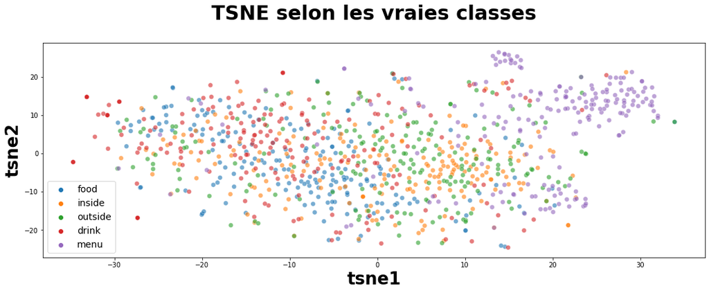

```
(1000, 4)
```

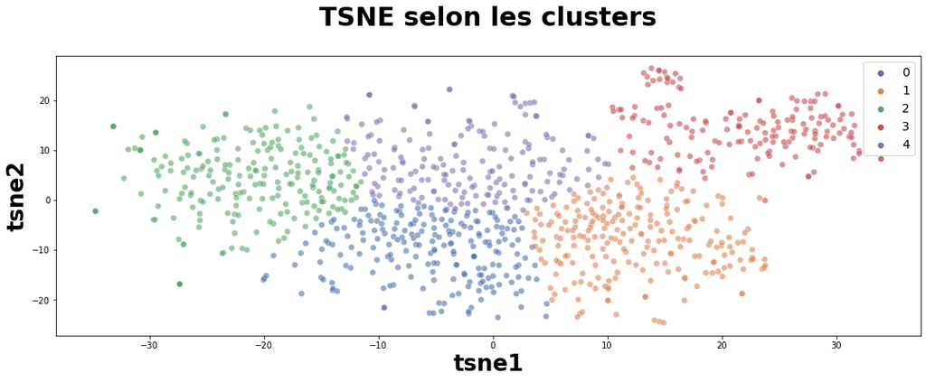

```
array(['food', 'inside', 'outside', 'drink', 'menu'], dtype=object)
```

### SCORE :

|  | file_name | label | clustering |
| --- | --- | --- | --- |
| 0 | pve7D6NUrafHW3EAORubyw.jpg | food | 0 |
| 1 | H52Er-uBg6rNrHcReWTD2w.jpg | food | 0 |
| 2 | wZ29mUm6nKz566j17OBadw.jpg | food | 0 |
| 3 | Le9rMdT8YFlvqr431LctIQ.jpg | food | 4 |
| 4 | 9kVdBkGWcKfCFzSwUXjQyw.jpg | food | 0 |
| 5 | dxIzVOEowFFsg2RmgFJZdQ.jpg | food | 0 |

|  | file_name | label |
| --- | --- | --- |
| 0 | pve7D6NUrafHW3EAORubyw.jpg | food |
| 1 | H52Er-uBg6rNrHcReWTD2w.jpg | food |
| 2 | wZ29mUm6nKz566j17OBadw.jpg | food |
| 3 | Le9rMdT8YFlvqr431LctIQ.jpg | food |
| 4 | 9kVdBkGWcKfCFzSwUXjQyw.jpg | food |
| ... | ... | ... |
| 995 | RKrucTfvnq9g9epbvCazXQ.jpg | menu |
| 996 | OqwkUDdPPVDNBQbCj_NB4A.jpg | menu |
| 997 | iZP8BCcCgN3Wtss09d8TRg.jpg | menu |
| 998 | GrLa_I3shzYn_hvtHuz54A.jpg | menu |
| 999 | oAXsOzMPinlujAXcXmRTfA.jpg | menu |

1000 rows × 2 columns

### Identification manuelle des paires : cluster/class

```
0    85
2    65
4    30
1    18
3     2
Name: clustering, dtype: int64
```

```
1    84
0    50
4    33
2    29
3     4
Name: clustering, dtype: int64
```

```
1    69
4    57
0    33
2    28
3    13
Name: clustering, dtype: int64
```

```
2    93
0    41
4    41
1    14
3    11
Name: clustering, dtype: int64
```

```
3    130
1     44
4     16
2      7
0      3
Name: clustering, dtype: int64
```

```
ARI :  0.15178503874306556
```

```
Accuracy =  0.449
```

```
f1-score =  0.4539195069594573
```

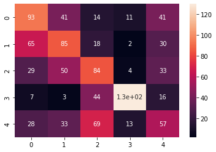

### Approche II : Image classification by CNN features extraction :

### Files input :

```
'pve7D6NUrafHW3EAORubyw.jpg'
```

```
'C:/Users/AMC/Desktop/Still_on_P/Projet - 06 - En cours/yelp_photos/photos/'
```

|  | file_name | label |
| --- | --- | --- |
| 0 | pve7D6NUrafHW3EAORubyw.jpg | food |
| 1 | H52Er-uBg6rNrHcReWTD2w.jpg | food |

### Test to load an image :

```
(224, 224, 3)
```

```
(1, 224, 224, 3)
```

```
151.061
-123.68
```

### Define CNN Model :

```
Model: "vgg16"
_________________________________________________________________
 Layer (type)                Output Shape              Param #
=================================================================
 input_1 (InputLayer)        [(None, 224, 224, 3)]     0

 block1_conv1 (Conv2D)       (None, 224, 224, 64)      1792

 block1_conv2 (Conv2D)       (None, 224, 224, 64)      36928

 block1_pool (MaxPooling2D)  (None, 112, 112, 64)      0

 block2_conv1 (Conv2D)       (None, 112, 112, 128)     73856

 block2_conv2 (Conv2D)       (None, 112, 112, 128)     147584

 block2_pool (MaxPooling2D)  (None, 56, 56, 128)       0

 block3_conv1 (Conv2D)       (None, 56, 56, 256)       295168

 block3_conv2 (Conv2D)       (None, 56, 56, 256)       590080

 block3_conv3 (Conv2D)       (None, 56, 56, 256)       590080

 block3_pool (MaxPooling2D)  (None, 28, 28, 256)       0

 block4_conv1 (Conv2D)       (None, 28, 28, 512)       1180160

 block4_conv2 (Conv2D)       (None, 28, 28, 512)       2359808

 block4_conv3 (Conv2D)       (None, 28, 28, 512)       2359808

 block4_pool (MaxPooling2D)  (None, 14, 14, 512)       0

 block5_conv1 (Conv2D)       (None, 14, 14, 512)       2359808

 block5_conv2 (Conv2D)       (None, 14, 14, 512)       2359808

 block5_conv3 (Conv2D)       (None, 14, 14, 512)       2359808

 block5_pool (MaxPooling2D)  (None, 7, 7, 512)         0

 flatten (Flatten)           (None, 25088)             0

 fc1 (Dense)                 (None, 4096)              102764544

 fc2 (Dense)                 (None, 4096)              16781312

 predictions (Dense)         (None, 1000)              4097000

=================================================================
Total params: 138,357,544
Trainable params: 138,357,544
Non-trainable params: 0
_________________________________________________________________
```

```
Model: "model"
_________________________________________________________________
 Layer (type)                Output Shape              Param #
=================================================================
 input_1 (InputLayer)        [(None, 224, 224, 3)]     0

 block1_conv1 (Conv2D)       (None, 224, 224, 64)      1792

 block1_conv2 (Conv2D)       (None, 224, 224, 64)      36928

 block1_pool (MaxPooling2D)  (None, 112, 112, 64)      0

 block2_conv1 (Conv2D)       (None, 112, 112, 128)     73856

 block2_conv2 (Conv2D)       (None, 112, 112, 128)     147584

 block2_pool (MaxPooling2D)  (None, 56, 56, 128)       0

 block3_conv1 (Conv2D)       (None, 56, 56, 256)       295168

 block3_conv2 (Conv2D)       (None, 56, 56, 256)       590080

 block3_conv3 (Conv2D)       (None, 56, 56, 256)       590080

 block3_pool (MaxPooling2D)  (None, 28, 28, 256)       0

 block4_conv1 (Conv2D)       (None, 28, 28, 512)       1180160

 block4_conv2 (Conv2D)       (None, 28, 28, 512)       2359808

 block4_conv3 (Conv2D)       (None, 28, 28, 512)       2359808

 block4_pool (MaxPooling2D)  (None, 14, 14, 512)       0

 block5_conv1 (Conv2D)       (None, 14, 14, 512)       2359808

 block5_conv2 (Conv2D)       (None, 14, 14, 512)       2359808

 block5_conv3 (Conv2D)       (None, 14, 14, 512)       2359808

 block5_pool (MaxPooling2D)  (None, 7, 7, 512)         0

 flatten (Flatten)           (None, 25088)             0

=================================================================
Total params: 14,714,688
Trainable params: 14,714,688
Non-trainable params: 0
_________________________________________________________________
```

#### output CNN

```
array([[ 0.      ,  0.      ,  0.      , ...,  0.      , 14.107786,
         0.      ],
       [ 0.      ,  0.      ,  0.      , ...,  0.      ,  6.693441,
         0.      ],
       [ 0.      ,  0.      ,  0.      , ...,  0.      ,  0.      ,
         0.      ],
       ...,
       [ 0.      ,  0.      ,  0.      , ...,  0.      ,  0.      ,
         0.      ],
       [ 0.      ,  0.      ,  0.      , ...,  0.      ,  0.      ,
         0.      ],
       [ 0.      ,  0.      ,  0.      , ...,  0.      ,  0.      ,
         0.      ]], dtype=float32)
```

|  | file_name | label |
| --- | --- | --- |
| 0 | pve7D6NUrafHW3EAORubyw.jpg | food |
| 1 | H52Er-uBg6rNrHcReWTD2w.jpg | food |
| 2 | wZ29mUm6nKz566j17OBadw.jpg | food |
| 3 | Le9rMdT8YFlvqr431LctIQ.jpg | food |
| 4 | 9kVdBkGWcKfCFzSwUXjQyw.jpg | food |
| 5 | dxIzVOEowFFsg2RmgFJZdQ.jpg | food |

### TSNE

```
(1000, 3)
```

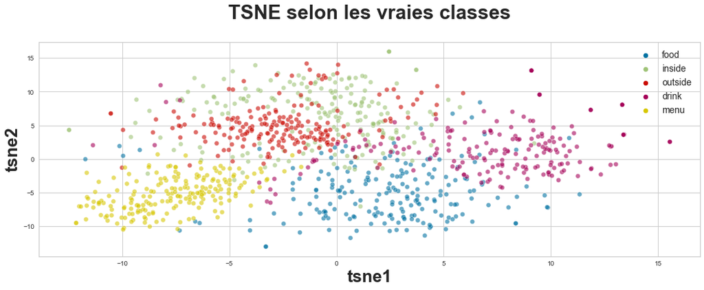

```
(1000, 4)
```

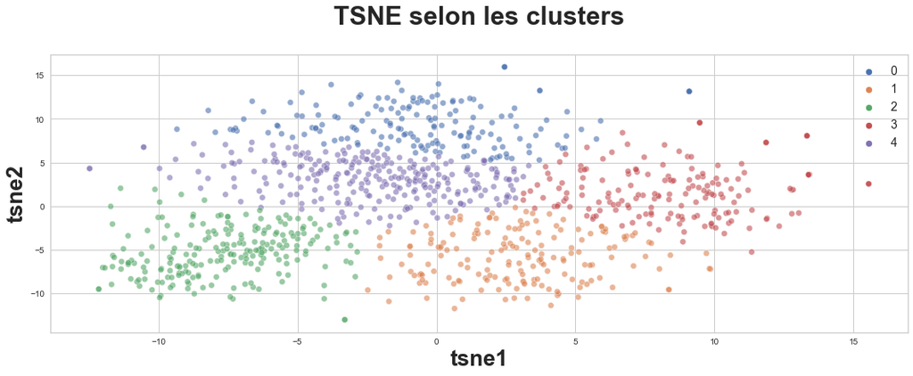

|  | file_name | label | clustering |
| --- | --- | --- | --- |
| 0 | pve7D6NUrafHW3EAORubyw.jpg | food | 1 |
| 1 | H52Er-uBg6rNrHcReWTD2w.jpg | food | 1 |
| 2 | wZ29mUm6nKz566j17OBadw.jpg | food | 1 |
| 3 | Le9rMdT8YFlvqr431LctIQ.jpg | food | 1 |
| 4 | 9kVdBkGWcKfCFzSwUXjQyw.jpg | food | 1 |
| ... | ... | ... | ... |
| 995 | RKrucTfvnq9g9epbvCazXQ.jpg | menu | 2 |
| 996 | OqwkUDdPPVDNBQbCj_NB4A.jpg | menu | 2 |
| 997 | iZP8BCcCgN3Wtss09d8TRg.jpg | menu | 2 |
| 998 | GrLa_I3shzYn_hvtHuz54A.jpg | menu | 2 |
| 999 | oAXsOzMPinlujAXcXmRTfA.jpg | menu | 2 |

1000 rows × 3 columns

```
1    157
3     16
4     15
2     12
Name: clustering, dtype: int64
```

```
0    117
4     69
3      6
1      5
2      3
Name: clustering, dtype: int64
```

```
4    154
0     43
2      2
1      1
Name: clustering, dtype: int64
```

```
3    151
4     22
1     10
0     10
2      7
Name: clustering, dtype: int64
```

```
2    194
4      6
Name: clustering, dtype: int64
```

|  | file_name | label | clustering | clustering_labels |
| --- | --- | --- | --- | --- |
| 0 | pve7D6NUrafHW3EAORubyw.jpg | food | 1 | food |
| 1 | H52Er-uBg6rNrHcReWTD2w.jpg | food | 1 | food |
| 2 | wZ29mUm6nKz566j17OBadw.jpg | food | 1 | food |

### SCORE

```
ARI :  0.5482373766061898
```

```
Accuracy =  0.773
```

```
f1-score =  0.7746161668687771
```

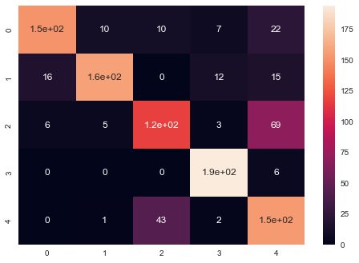

# Partie 03: YELP API TO EXTRACT RESTAURANT INFO

What is an API? An API is an interface between two different systems. It’s like a bridge that allows the client and host to exchange data. Actions performed by an API to a dataset are categorized as create, read, update, and delete – more commonly known as CRUD. The information pushed or pulled from the source often comes in either an XML or JSON format. In the case of Yelp Fusion API, data is returned in JSON. One of the main advantages of an API is that it allows authorized or open access to specific data, allowing the data owner to keep their system separate from 3rd party components. This creates a decoupling effect where the 3rd party isn’t required to natively integrate into the host’s systems. Data exposure is also limited by the host, allowing for seamless versioning and support.

```
True
```

### Restaurants data gathering :

#### Business data :

[output not shown]

[output cut: 345 more lines]

[output not shown]

|  | id | alias | name | image_url | is_closed | url | review_count | categories | rating | coordinates | transactions | price | location | phone | display_phone | distance |
| --- | --- | --- | --- | --- | --- | --- | --- | --- | --- | --- | --- | --- | --- | --- | --- | --- |
| 0 | W0sXHSSpkiMEDJiBmSLNYQ | trestle-astoria | Trestle | https://s3-media2.fl.yelpcdn.com/bphoto/OqbqzUDibIw5hLL5M2xH2A/o.jpg | False | https://www.yelp.com/biz/trestle-astoria?adjust_creative=A57LwVZ5W7txZHbVlG9Tnw&utm_campaign=yelp_api_v3&utm_medium=api_v3_business_search&utm_source=A57LwVZ5W7txZHbVlG9Tnw | 477 | [{'alias': 'cocktailbars', 'title': 'Cocktail Bars'}, {'alias': 'newamerican', 'title': 'American (New)'}, {'alias': 'breakfast_brunch', 'title': 'Breakfast & Brunch'}] | 4.5 | {'latitude': 40.7606154, 'longitude': -73.9229562} | [delivery, restaurant_reservation, pickup] | $$ | {'address1': '34-02 Broadway', 'address2': '', 'address3': None, 'city': 'Astoria', 'zip_code': '11106', 'country': 'US', 'state': 'NY', 'display_address': ['34-02 Broadway', 'Astoria, NY 11106']} | +13478080290 | (347) 808-0290 | 700.500655 |
| 1 | _HBpi2PIG8Zxz01Pr41MIw | the-shady-lady-astoria | The Shady Lady | https://s3-media3.fl.yelpcdn.com/bphoto/79PjiSqvqypIJgv1NfwhUQ/o.jpg | False | https://www.yelp.com/biz/the-shady-lady-astoria?adjust_creative=A57LwVZ5W7txZHbVlG9Tnw&utm_campaign=yelp_api_v3&utm_medium=api_v3_business_search&utm_source=A57LwVZ5W7txZHbVlG9Tnw | 970 | [{'alias': 'breakfast_brunch', 'title': 'Breakfast & Brunch'}, {'alias': 'bars', 'title': 'Bars'}, {'alias': 'comfortfood', 'title': 'Comfort Food'}] | 4.0 | {'latitude': 40.765619, 'longitude': -73.9181399} | [delivery, pickup] | $$ | {'address1': '34-19 30th Ave', 'address2': '', 'address3': '', 'city': 'Astoria', 'zip_code': '11103', 'country': 'US', 'state': 'NY', 'display_address': ['34-19 30th Ave', 'Astoria, NY 11103']} | +17184409081 | (718) 440-9081 | 369.576424 |
| 2 | uQ0kF3fiJFDm0oDVRaMBkw | carla-long-island-city | Carla | https://s3-media4.fl.yelpcdn.com/bphoto/BoE34winfFNgMlZ5Hnhdng/o.jpg | False | https://www.yelp.com/biz/carla-long-island-city?adjust_creative=A57LwVZ5W7txZHbVlG9Tnw&utm_campaign=yelp_api_v3&utm_medium=api_v3_business_search&utm_source=A57LwVZ5W7txZHbVlG9Tnw | 105 | [{'alias': 'newamerican', 'title': 'American (New)'}, {'alias': 'burgers', 'title': 'Burgers'}, {'alias': 'cocktailbars', 'title': 'Cocktail Bars'}] | 4.5 | {'latitude': 40.75351, 'longitude': -73.93764} | [delivery] | $$ | {'address1': '25-03 40th Avenue', 'address2': '', 'address3': None, 'city': 'Long Island City', 'zip_code': '11101', 'country': 'US', 'state': 'NY', 'display_address': ['25-03 40th Avenue', 'Long Isla… | +19292046264 | (929) 204-6264 | 1976.266628 |
| 3 | k5bGHJbAXDw9g_uP42QqDw | the-highwater-astoria | The Highwater | https://s3-media1.fl.yelpcdn.com/bphoto/0TwP96PRTfM1lNRt_1zTxQ/o.jpg | False | https://www.yelp.com/biz/the-highwater-astoria?adjust_creative=A57LwVZ5W7txZHbVlG9Tnw&utm_campaign=yelp_api_v3&utm_medium=api_v3_business_search&utm_source=A57LwVZ5W7txZHbVlG9Tnw | 481 | [{'alias': 'newamerican', 'title': 'American (New)'}, {'alias': 'tikibars', 'title': 'Tiki Bars'}, {'alias': 'breakfast_brunch', 'title': 'Breakfast & Brunch'}] | 4.0 | {'latitude': 40.76033, 'longitude': -73.92245} | [delivery, restaurant_reservation, pickup] | $$ | {'address1': '3420 Broadway', 'address2': None, 'address3': '', 'city': 'Astoria', 'zip_code': '11106', 'country': 'US', 'state': 'NY', 'display_address': ['3420 Broadway', 'Astoria, NY 11106']} | +19177450407 | (917) 745-0407 | 725.267313 |
| 4 | zgW7g4RWssKfjdlSE8fZvg | sweet-afton-astoria | Sweet Afton | https://s3-media1.fl.yelpcdn.com/bphoto/7qRjy07rSq9Q62H2jQKt3w/o.jpg | False | https://www.yelp.com/biz/sweet-afton-astoria?adjust_creative=A57LwVZ5W7txZHbVlG9Tnw&utm_campaign=yelp_api_v3&utm_medium=api_v3_business_search&utm_source=A57LwVZ5W7txZHbVlG9Tnw | 1118 | [{'alias': 'bars', 'title': 'Bars'}, {'alias': 'gastropubs', 'title': 'Gastropubs'}, {'alias': 'breakfast_brunch', 'title': 'Breakfast & Brunch'}] | 4.0 | {'latitude': 40.765352, 'longitude': -73.918983} | [delivery, pickup] | $$ | {'address1': '30-09 34th St', 'address2': '', 'address3': '', 'city': 'Astoria', 'zip_code': '11103', 'country': 'US', 'state': 'NY', 'display_address': ['30-09 34th St', 'Astoria, NY 11103']} | +17187772570 | (718) 777-2570 | 319.987759 |
| ... | ... | ... | ... | ... | ... | ... | ... | ... | ... | ... | ... | ... | ... | ... | ... | ... |
| 45 | DgaaiJq0ji-Wyx7yYLUVwQ | chilis-boise-3 | Chili's | https://s3-media1.fl.yelpcdn.com/bphoto/aTxyZv5cNlhKOVY8-3Hj0g/o.jpg | False | https://www.yelp.com/biz/chilis-boise-3?adjust_creative=A57LwVZ5W7txZHbVlG9Tnw&utm_campaign=yelp_api_v3&utm_medium=api_v3_business_search&utm_source=A57LwVZ5W7txZHbVlG9Tnw | 62 | [{'alias': 'tradamerican', 'title': 'American (Traditional)'}, {'alias': 'bars', 'title': 'Bars'}, {'alias': 'tex-mex', 'title': 'Tex-Mex'}] | 2.5 | {'latitude': 43.601484, 'longitude': -116.193054} | [pickup, delivery] | $$ | {'address1': '916 S Broadway Ave', 'address2': '', 'address3': '', 'city': 'Boise', 'zip_code': '83706', 'country': 'US', 'state': 'ID', 'display_address': ['916 S Broadway Ave', 'Boise, ID 83706']} | +12083892200 | (208) 389-2200 | 4209.349513 |
| 46 | sf4vifuAJgIkqYp6eUC7-g | prost-boise-boise | Prost! Boise | https://s3-media3.fl.yelpcdn.com/bphoto/jNGaRuWZfKk6zirKIQzOsA/o.jpg | False | https://www.yelp.com/biz/prost-boise-boise?adjust_creative=A57LwVZ5W7txZHbVlG9Tnw&utm_campaign=yelp_api_v3&utm_medium=api_v3_business_search&utm_source=A57LwVZ5W7txZHbVlG9Tnw | 135 | [{'alias': 'german', 'title': 'German'}, {'alias': 'beerbar', 'title': 'Beer Bar'}] | 4.0 | {'latitude': 43.6168137, 'longitude': -116.2021173} | [delivery] | $$ | {'address1': '274 N 8th St', 'address2': '', 'address3': '', 'city': 'Boise', 'zip_code': '83702', 'country': 'US', 'state': 'ID', 'display_address': ['274 N 8th St', 'Boise, ID 83702']} | +12083369395 | (208) 336-9395 | 3390.530997 |
| 47 | -l3G5kG-LuiKe6Eqy3KKZw | sids-garage-meridian-2 | Sids Garage | https://s3-media2.fl.yelpcdn.com/bphoto/zi9BbGFGqTi7pLNNaD_VYA/o.jpg | False | https://www.yelp.com/biz/sids-garage-meridian-2?adjust_creative=A57LwVZ5W7txZHbVlG9Tnw&utm_campaign=yelp_api_v3&utm_medium=api_v3_business_search&utm_source=A57LwVZ5W7txZHbVlG9Tnw | 233 | [{'alias': 'burgers', 'title': 'Burgers'}, {'alias': 'newamerican', 'title': 'American (New)'}, {'alias': 'breweries', 'title': 'Breweries'}] | 4.0 | {'latitude': 43.62124110497864, 'longitude': -116.350240897065} | [delivery] | $$ | {'address1': '3525 E Longwing Ln', 'address2': 'Ste 180', 'address3': '', 'city': 'Meridian', 'zip_code': '83646', 'country': 'US', 'state': 'ID', 'display_address': ['3525 E Longwing Ln', 'Ste 180', … | +12085193092 | (208) 519-3092 | 8658.189084 |
| 48 | k66N-4OusE74AAbUR9L1Tg | juniper-boise-2 | Juniper | https://s3-media4.fl.yelpcdn.com/bphoto/wah9JpvTiMWtRcRA5iXRjg/o.jpg | False | https://www.yelp.com/biz/juniper-boise-2?adjust_creative=A57LwVZ5W7txZHbVlG9Tnw&utm_campaign=yelp_api_v3&utm_medium=api_v3_business_search&utm_source=A57LwVZ5W7txZHbVlG9Tnw | 427 | [{'alias': 'newamerican', 'title': 'American (New)'}, {'alias': 'cocktailbars', 'title': 'Cocktail Bars'}, {'alias': 'salad', 'title': 'Salad'}] | 4.0 | {'latitude': 43.61690795302801, 'longitude': -116.20249484110451} | [delivery] | $$ | {'address1': '211 N 8th St', 'address2': '', 'address3': '', 'city': 'Boise', 'zip_code': '83702', 'country': 'US', 'state': 'ID', 'display_address': ['211 N 8th St', 'Boise, ID 83702']} | +12083421142 | (208) 342-1142 | 3369.313887 |
| 49 | JdhXCnAG77iY6f0TLPaQ6A | solid-grill-and-bar-boise | Solid Grill and Bar | https://s3-media1.fl.yelpcdn.com/bphoto/XP1MSdJ_OsmCRYjYrsq0ow/o.jpg | False | https://www.yelp.com/biz/solid-grill-and-bar-boise?adjust_creative=A57LwVZ5W7txZHbVlG9Tnw&utm_campaign=yelp_api_v3&utm_medium=api_v3_business_search&utm_source=A57LwVZ5W7txZHbVlG9Tnw | 208 | [{'alias': 'tradamerican', 'title': 'American (Traditional)'}, {'alias': 'bars', 'title': 'Bars'}] | 3.5 | {'latitude': 43.613286, 'longitude': -116.205998} | [delivery] | $$ | {'address1': '405 S 8th St', 'address2': '', 'address3': '', 'city': 'Boise', 'zip_code': '83702', 'country': 'US', 'state': 'ID', 'display_address': ['405 S 8th St', 'Boise, ID 83702']} | +12083456620 | (208) 345-6620 | 3035.632066 |

200 rows × 16 columns

```
0
```

```
(200, 16)
```

#### Reviews of business we extracted :

```
['W0sXHSSpkiMEDJiBmSLNYQ',
 '_HBpi2PIG8Zxz01Pr41MIw',
 'uQ0kF3fiJFDm0oDVRaMBkw',
 'k5bGHJbAXDw9g_uP42QqDw',
 'CpZ5fw9rxHOdLmdtW1Qdbw',
 'zgW7g4RWssKfjdlSE8fZvg',
 'rrsjcQVLg2PkIkO_vPjOLw',
 'AawLwOYZwMf_9wkShExfuw',
 '5ZWX85Le2vNrtAw5s9lHdQ',
 'H5bhfR5sL0I2w1csjI1uMA',
 'mWS4umRg2AyykyAClMrIRw',
 'gJmJDwrDUHy--3qS9qQFYA',
 'AUyKmFjpaVLwc3awfUnqgQ',
 'iNiq1vgWpEa48jlPAce8wQ',
 '6AJwsgXr7YwsqneGVAdgzw',
 '47_jHPl3p4-OYGCVLy2ZIA',
 '3UmRGpZsMdJx4fWCT1NxZg',
 'azOGJ8gBsP4RF2zOJTSwDg',
 'abZ-mEvF6Tj4hfyIg0lKwQ',
 '0jswXSAOU-a5VTR3n7Yebw',
 'ayOj0JXAsuGqVG8reuqpxQ',
 'Z3mYawowd-Uq-wJyASMskQ',
 'YKoQUUrUdE_XHw-ikAkumQ',
 'Sj3JYCbaEFrAqUzRrenQbg',
 'GojmCdGjUyGPxGLpoxXhvA',
 'Y98a2y3r77l7S4wVS4Vqzg',
 'yczK4BwiadrSLAhVZw87BQ',
 'l_hBcWIFx_ausYBxLkSglQ',
 'wT_-RVwMoiPAL9L191Zjvg',
 'P-XnPhzdGbgbMYIcS0cpTA',
 '1ExwosnCMtb7D3SF5ovo6w',
 '-0fjWWC2SY6kNxGfD8PKGg',
 'kzd10IXi3dTjoPw0TDj8tA',
 'UF9F0A4e7AJHzNPG5zrHUQ',
 'LBiuVnEqHa-tsmKzMZPfiQ',
 'B9aM47OiOJtoBKOGY3aMQw',
 'pL7MK_PsDtrKdBm1xLPzkg',
 'ElAv3e3Iw8OnicWwnOzm-A',
 '2_zM-VTPBINeV74yqlho9w',
 'Hh9glEE_xDYT_pPUsRPXlA',
```

[output cut: 145 more lines]

```
 'qhRq6HPGNn1BYojzDdkgRA',
 'SwB8Xh8m-sjJJ4XwW8kEWg',
 '-l3G5kG-LuiKe6Eqy3KKZw',
 'k66N-4OusE74AAbUR9L1Tg',
 'NvmCO5xNbN41IRN5mxXUEg',
 'Tojvtx2B5aSTnWcMdXQ7rw',
 'OjHQumZ6nCh5vqzUbmkaNg',
 'mdb_Ri2eqVGG1C-7Cuyplg',
 'BWtJHJRc4cv6-ND1C_5QpA',
 'dqyijU3ditWPJKxPgR3qAQ',
 'D6_CwyzXFJsBTaKgw8GqYg',
 'JdhXCnAG77iY6f0TLPaQ6A',
 '4FaYG9qKDpDyr68bKmaIEw',
 'frvkIC6OAwgnQNsxjce_GA',
 'sf4vifuAJgIkqYp6eUC7-g']
```

```
0    W0sXHSSpkiMEDJiBmSLNYQ
0    X8EmtgsqlB9QHJ7HH-FiIw
0    iC07-jSfyOWxKBqYH658kw
0    -T-hEoNi7KRHtKEUWeckUw
Name: id, dtype: object
```

```
{'reviews': [{'id': 'MThn1on0LwHvjIoPyKOBfw',
   'url': 'https://www.yelp.com/biz/taco-tumba-astoria?adjust_creative=A57LwVZ5W7txZHbVlG9Tnw&hrid=MThn1on0LwHvjIoPyKOBfw&utm_campaign=yelp_api_v3&utm_medium=api_v3_business_reviews&utm_source=A57LwVZ5W7txZHbVlG9Tnw',
   'text': "I visited Taco Tumba last night for my friend's birthday and I LOVED it here!\n\nThe bartenders were friendly and welcoming (they were also all gorgeous). I...",
   'rating': 5,
   'time_created': '2022-07-13 07:16:30',
   'user': {'id': 'Yp8wVKuFxJermr2yy6cV8g',
    'profile_url': 'https://www.yelp.com/user_details?userid=Yp8wVKuFxJermr2yy6cV8g',
    'image_url': 'https://s3-media1.fl.yelpcdn.com/photo/vZ4k1zc_Yty9ldeBr2Q7hg/o.jpg',
    'name': 'Lisa T.'}},
  {'id': 'SjARlWqpZrn2A3uTNYV3LA',
   'url': 'https://www.yelp.com/biz/taco-tumba-astoria?adjust_creative=A57LwVZ5W7txZHbVlG9Tnw&hrid=SjARlWqpZrn2A3uTNYV3LA&utm_campaign=yelp_api_v3&utm_medium=api_v3_business_reviews&utm_source=A57LwVZ5W7txZHbVlG9Tnw',
   'text': 'So perf!\n\nHey Yelpers!\n\nHonestly,\n\nK found this place off tiktok n insta so I was hesitant... but loved every minute here. Showed up for a 5:15 res and left...',
   'rating': 5,
   'time_created': '2022-07-12 17:50:25',
   'user': {'id': 'Hd6r_o5dUsMJHtJPi9CxmA',
    'profile_url': 'https://www.yelp.com/user_details?userid=Hd6r_o5dUsMJHtJPi9CxmA',
    'image_url': 'https://s3-media1.fl.yelpcdn.com/photo/Zk9TTXi3gdYTPLYKo2bEjA/o.jpg',
    'name': 'Christian V.'}},
  {'id': 'MI-1EdXO7fm0_FveYddtNA',
   'url': 'https://www.yelp.com/biz/taco-tumba-astoria?adjust_creative=A57LwVZ5W7txZHbVlG9Tnw&hrid=MI-1EdXO7fm0_FveYddtNA&utm_campaign=yelp_api_v3&utm_medium=api_v3_business_reviews&utm_source=A57LwVZ5W7txZHbVlG9Tnw',
   'text': 'I was so excited to come here after I attended the Yelp Elite event last week! I was raving to my friend about it so we decided to grab dinner!\nWe ordered...',
   'rating': 2,
   'time_created': '2022-05-20 08:38:21',
   'user': {'id': 'UgmEv9x7aKOrSuesgpy-pQ',
    'profile_url': 'https://www.yelp.com/user_details?userid=UgmEv9x7aKOrSuesgpy-pQ',
    'image_url': 'https://s3-media3.fl.yelpcdn.com/photo/qaWKhaWkTOnV5wucUDbupA/o.jpg',
    'name': 'Angela G.'}}],
 'total': 78,
 'possible_languages': ['en', 'es']}
```

```
0
W0sXHSSpkiMEDJiBmSLNYQ
```

```
1
_HBpi2PIG8Zxz01Pr41MIw
```

```
2
uQ0kF3fiJFDm0oDVRaMBkw
```

```
3
k5bGHJbAXDw9g_uP42QqDw
```

```
4
CpZ5fw9rxHOdLmdtW1Qdbw
```

```
5
zgW7g4RWssKfjdlSE8fZvg
```

```
6
rrsjcQVLg2PkIkO_vPjOLw
```

```
7
AawLwOYZwMf_9wkShExfuw
```

```
8
5ZWX85Le2vNrtAw5s9lHdQ
```

```
9
H5bhfR5sL0I2w1csjI1uMA
```

```
10
mWS4umRg2AyykyAClMrIRw
```

```
11
gJmJDwrDUHy--3qS9qQFYA
```

```
12
AUyKmFjpaVLwc3awfUnqgQ
```

```
13
iNiq1vgWpEa48jlPAce8wQ
```

```
14
6AJwsgXr7YwsqneGVAdgzw
```

```
15
47_jHPl3p4-OYGCVLy2ZIA
```

```
16
3UmRGpZsMdJx4fWCT1NxZg
```

```
17
azOGJ8gBsP4RF2zOJTSwDg
```

```
18
abZ-mEvF6Tj4hfyIg0lKwQ
```

```
19
0jswXSAOU-a5VTR3n7Yebw
```

```
20
ayOj0JXAsuGqVG8reuqpxQ
```

```
21
Z3mYawowd-Uq-wJyASMskQ
```

```
22
YKoQUUrUdE_XHw-ikAkumQ
```

```
23
Sj3JYCbaEFrAqUzRrenQbg
```

```
24
GojmCdGjUyGPxGLpoxXhvA
```

```
25
Y98a2y3r77l7S4wVS4Vqzg
```

```
26
yczK4BwiadrSLAhVZw87BQ
```

```
27
l_hBcWIFx_ausYBxLkSglQ
```

```
28
wT_-RVwMoiPAL9L191Zjvg
```

```
29
P-XnPhzdGbgbMYIcS0cpTA
```

```
30
1ExwosnCMtb7D3SF5ovo6w
```

```
31
-0fjWWC2SY6kNxGfD8PKGg
```

```
32
kzd10IXi3dTjoPw0TDj8tA
```

```
33
UF9F0A4e7AJHzNPG5zrHUQ
```

```
34
LBiuVnEqHa-tsmKzMZPfiQ
```

```
35
B9aM47OiOJtoBKOGY3aMQw
```

```
36
pL7MK_PsDtrKdBm1xLPzkg
```

```
37
ElAv3e3Iw8OnicWwnOzm-A
```

```
38
2_zM-VTPBINeV74yqlho9w
```

```
39
Hh9glEE_xDYT_pPUsRPXlA
```

```
40
ydWmJqho-8-8Nj1MVYliBg
```

```
41
EHUNrnIgnhwTnpOm3gEESg
```

```
42
Swjm9no7DRqhThLlf0EHng
```

```
43
QCRpLBLWl2IN3htaJeu2Xw
```

```
44
gj6zDB5krFzL90qdmpYVTQ
```

```
45
OAqsZMbjv66nOMqlimnYuQ
```

```
46
X-fUyfwKJKXRoImLvs_omg
```

```
47
MyQV4i518ZO4CLudtR8gLA
```

```
48
WEhkGLKlj-5X1pq_07Syaw
```

```
49
5PIEHs-0Jv-tS8bjDrypew
```

```
50
X8EmtgsqlB9QHJ7HH-FiIw
```

```
51
3Rs0SiK4KyzudB0B698b1A
```

```
52
lePcuWe7_C7pa48xgYsMIg
```

```
53
LljxHSN7eQ5A00-0AbBReA
```

```
54
_8y1B0HMhc3m9aLiVpp80w
```

```
55
IuX5vCDzmHzjbNi3wRD5Nw
```

```
56
c8Y6PrHgxx7eRsR2M4w5RA
```

```
57
gh1r0PvTWoTpjcj2JW4c8w
```

```
58
_9ZmF01-DpEUvZz4c-G1HQ
```

```
59
7g8CKU-UqEJ4bnIH2G5HCQ
```

```
60
Sa_qcnc7ZgzSOylf3plTRA
```

```
61
RXn_bE7f3eSpCvDOY06tQQ
```

```
62
f2OSK_d_bQTgIfi_Pp4zLA
```

```
63
ul3LRArpm9Efa4kK1fsdHg
```

```
64
fK767jP2s4CsOt2cfflqQQ
```

```
65
jpamJPEExKW9Y22JGXhdFw
```

```
66
30t5UxqCIdPnRVD_RpSVyQ
```

```
67
BNKrRIjY-WHU1qjzvOL8Mw
```

```
68
ah1wsendgkhUtTSR-MVDZw
```

```
69
xZIJZGJY2cFzVjFuWPGRFg
```

```
70
6kZTye2kYSTDc9YuJkY_Bw
```

```
71
-O-9y0Ax0WKZniG6t8VTQw
```

```
72
KQxQrE5daD4Ggd6URbhK5w
```

```
73
Fe1UM1XZRe8Pp3bwZecAvg
```

```
74
ovS5ddNNiABiLydUPr1duQ
```

```
75
moCQjz81wFD_Hg_EG0hE5w
```

```
76
PudSXGES4Xg2O1Q5Y0UWnw
```

```
77
aY_z6z6at7wyoW7sFhf4bA
```

```
78
ArSgukAJfUlEQu12GSA-qA
```

```
79
v1r1ZUcX2Xa8MijwF8dtrw
```

```
80
Bkd75R-s2jVt-euwJAyBZA
```

```
81
0es2F2zTINRvy719_AwrQQ
```

```
82
KOOk4d6SeSF2X6ifmJH4SA
```

```
83
cLwRI_vUBlqRRlKWxCi--w
```

```
84
scWXekmNj7Dq4bFB0tdUwQ
```

```
85
rgB0MQ11LDwn8_MtZtktDA
```

```
86
y9svW2He2TO9UeIvEVdg-A
```

```
87
s47V3FGY6JLX91syCV_HaA
```

```
88
CBZUZCTTGKMyAo757_NJew
```

```
89
2rQqfxtTimDObQn_je81-w
```

```
90
_0yupuQVwUC_E2KE5q-M4w
```

```
91
L2YgRsIyK-26DvBN9PUdhA
```

```
92
48IFYYRKXAlCn1JbCV3_bA
```

```
93
TC4WrRzvOpUQG6klahuNBQ
```

```
94
pnsWrEu31Bf0jCt8oHK3iA
```

```
95
cJ0cl1xWCfltfObttNceJA
```

```
96
SJOaN8Hf0IlJc_8qlot_jw
```

```
97
50CeD524LsISMTin6VLRJA
```

```
98
z6YZ1scNDqk6tj0FIapgwA
```

```
99
YLV7ZZoyOAXW3eqidGXBZA
```

```
100
iC07-jSfyOWxKBqYH658kw
```

```
101
HqymTJou4vGqyD4JG7a52w
```

```
102
sB9faEfqxKeDC_YtCuN9Ng
```

```
103
pfyNG7R2Dcc0iSf5R1RaCg
```

```
104
W5DFAhe0_ehmg0R7BIPsVQ
```

```
105
VwG-Nb3WyRxyQTC9BBgQcQ
```

```
106
XDUlenDAc_hy7FesXFbeTg
```

```
107
Iu2HchNKblA3i_t9KPdm9w
```

```
108
-ZrkUsV1EL_z1oEV5kG1Iw
```

```
109
b8VJtijPFIrpF3XOPZ7Xww
```

```
110
nip9nsCvOmImYo4aOsT-Dw
```

```
111
A6dQIVLdispbV3LiLWHjTg
```

```
112
vMklpKjIRywDvQm3YbjEYg
```

```
113
WUXa9xPjs8qwIO3gJ8qRkg
```

```
114
VadlyxjbtY72sayPrw0ing
```

```
115
TRnsmsvxV5lfKVbU3smWXA
```

```
116
gWtVOApXq3xaA9Y-iAMgUA
```

```
117
ac6G-_J7So7PJjYmcwzoWw
```

```
118
K7sNui75L0rZO1qnFWtnEw
```

```
119
e24z61Mu004KRaFNaP-36w
```

```
120
JfgI0_6DFtopbLxz1HZ5Ew
```

```
121
H-US2wdVba6DtG87K_vfiQ
```

```
122
QG5Dm6PxOVPAlbF6JRXFhA
```

```
123
DJYuzDKS__pFhf7Ogf5h_w
```

```
124
8L-HMfOdOh5qFTAb1iEBig
```

```
125
9QxKNx8IXPQT25IRIUWEdg
```

```
126
98i7iJ00xIm0qDytcrQGMA
```

```
127
f2TkM9bmBuSSo6N76E1Zog
```

```
128
Q7l6_-G9CPKtBSOEshBzCw
```

```
129
CPMcCTjvgFJqEM-bUDs1fw
```

```
130
ddpWZ82McHcm-MUxf1L6cw
```

```
131
7GVAE88l_dPdB2FUsKbdbg
```

```
132
ru4owJTAdPq24wZ_mcL_Tg
```

```
133
czcr4d0cfYGFNMDREswy0w
```

```
134
lxKAjt9j2746cZdSbGOoJA
```

```
135
1IuI57adM0kWgQqtyGwQWw
```

```
136
gCluZNRUuGvK0Bpkm6Hk3w
```

```
137
6sYL0H_J0U-FhsPJA5jGIw
```

```
138
cPGQGpM1G0KbNxn_7Uye8g
```

```
139
HUIPQBdRoGEcrQQC7sRNBQ
```

```
140
MzvA5K4JeqEq2pcBiMrbbw
```

```
141
dMPm52NE-2SQvT1QGTsD3Q
```

```
142
p6MjDlvD8CFCaXpDcT05qA
```

```
143
f7hQeRfU-19QlAKaHzRs-Q
```

```
144
dH960-1y9PD-LgSdD9pJ5Q
```

```
145
AounS6t9SQuhbmVyxstxTA
```

```
146
D86V20Y6EVkXUPHTHrWWYQ
```

```
147
xXOnDF2zdJmxnMySpAzgqA
```

```
148
lDHozV5T1I0p4uA0m0u3Kw
```

```
149
xOzdb9hZBH7UkuddmOYR4Q
```

```
150
-T-hEoNi7KRHtKEUWeckUw
```

```
151
-0jzoPt3UeXn6FUXVQvyPg
```

```
152
w_4xUt-1AyY2ZwKtnjW0Xg
```

```
153
MPzHj7-_3DbwQLOIJ6Tf1Q
```

```
154
deekBOsX4tKZMect5l4pfg
```

```
155
28Q07HstcPUjj_WaqI-8DA
```

```
156
tZ_lWpM_VJrpg41rl7QDRg
```

```
157
zDGmQSlg9GEmaY2ptN5L5A
```

```
158
YMbv9x8yL9X4nEReU0gPIA
```

```
159
CHbADBd6bCF_ZsC5g15y-w
```

```
160
L_EVdc2xdI6VSIH9LIXOig
```

```
161
jbJTF1zVmZsk4hea8hoeVA
```

```
162
7bJGh3PkW9tr3rXC6P2uwA
```

```
163
eTTssCbD8nmU4sc4M5gqPw
```

```
164
Ps8KgiyJhPqhkjWBklPimg
```

```
165
3X2pmXKqaMQ6xZjJHlKn8w
```

```
166
aQxjAaKB-KMjU_cFxNnTTQ
```

```
167
dv1Ua07Jtcrny5OB6IeEKA
```

```
168
-BFrwPGCH-22kRPvFrFk4Q
```

```
169
8PydwFenDDgKgV768QwgEg
```

```
170
nFDvzfl84x1y3NMBcjqdbQ
```

```
171
BoIt6TtgioNRp8zCRXMWzg
```

```
172
TbxnO7v3mbfonyQ4FhLMfw
```

```
173
l6vfUuv9KRsCC7WV5he2gg
```

```
174
WgI6eGxqF90X5AF1bv0WNQ
```

```
175
snTpO07JxjGhwJbE4RDFIA
```

```
176
7GSOAWAlmIvKdbAVFBL_Cw
```

```
177
7I7sH0CA9d8nC-ITIxc5Pg
```

```
178
6VDSx-ghQwbYvMaS0fz9xw
```

```
179
1LLXrKlTbnKGVLvJQ72Xpw
```

```
180
Pz4BjuaA6cjF0FeC6j-dmw
```

```
181
DgaaiJq0ji-Wyx7yYLUVwQ
```

```
182
jvsdP8Sm9z56xyrMXansbA
```

```
183
ciBiwtengE4sbsThPpeVpQ
```

```
184
9xOXtVsQxb81rTXLz9T1HQ
```

```
185
qhRq6HPGNn1BYojzDdkgRA
```

```
186
SwB8Xh8m-sjJJ4XwW8kEWg
```

```
187
-l3G5kG-LuiKe6Eqy3KKZw
```

```
188
k66N-4OusE74AAbUR9L1Tg
```

```
189
NvmCO5xNbN41IRN5mxXUEg
```

```
190
Tojvtx2B5aSTnWcMdXQ7rw
```

```
191
OjHQumZ6nCh5vqzUbmkaNg
```

```
192
mdb_Ri2eqVGG1C-7Cuyplg
```

```
193
BWtJHJRc4cv6-ND1C_5QpA
```

```
194
dqyijU3ditWPJKxPgR3qAQ
```

```
195
D6_CwyzXFJsBTaKgw8GqYg
```

```
196
JdhXCnAG77iY6f0TLPaQ6A
```

```
197
4FaYG9qKDpDyr68bKmaIEw
```

```
198
frvkIC6OAwgnQNsxjce_GA
```

```
199
sf4vifuAJgIkqYp6eUC7-g
```

```
(150, 7)
```

|  | id | url | text | rating | time_created | user | business_id |
| --- | --- | --- | --- | --- | --- | --- | --- |
| 0 | 8vxcG-frKT45XxKDdyRTjQ | https://www.yelp.com/biz/trestle-astoria?adjus... | This was my first time here at Trestle with my... | 5 | 2022-07-08 21:55:51 | {'id': 'wARPT6TBllO2szkkhhjufA', 'profile_url'... | W0sXHSSpkiMEDJiBmSLNYQ |
| 1 | gaOle31H1e3GL0Kpyf6Yaw | https://www.yelp.com/biz/trestle-astoria?adjus... | Nice vibes in here. I came on a humble. Alone ... | 5 | 2022-07-24 04:35:49 | {'id': 'QuWYxm3ij1Qsa9mUH371Xw', 'profile_url'... | W0sXHSSpkiMEDJiBmSLNYQ |
| 2 | vwHOl0_1T7EXZV1tDpa_uQ | https://www.yelp.com/biz/trestle-astoria?adjus... | Food was good and the seat booth was solid sea... | 4 | 2022-07-23 18:08:53 | {'id': 'PewlvbzvPSzVj2WnVZ7s4w', 'profile_url'... | W0sXHSSpkiMEDJiBmSLNYQ |
| 0 | 0-TtFH40vsPthH7Css5lfg | https://www.yelp.com/biz/the-shady-lady-astori... | I walked in without a reservation on 1:30 pm i... | 5 | 2022-06-18 05:51:34 | {'id': 'FmLwFMr885MIFgcHk631Cg', 'profile_url'... | _HBpi2PIG8Zxz01Pr41MIw |
| 1 | Nlb6aW0RlggxXoW-Jt4KEw | https://www.yelp.com/biz/the-shady-lady-astori... | I had a good time here during happy hour. $7 m... | 5 | 2022-06-09 07:30:13 | {'id': 'sBjpUbgILjlck5BD-flF9Q', 'profile_url'... | _HBpi2PIG8Zxz01Pr41MIw |